# Overview Doc

Brian Law

November 24, 2015

This is an overview attempt of the Model Selection with R short course organsied by the Centre for Applied Statistics at UWA.

This course covers model selection with linear models.

Model selection techniques centered around Residual Sum of Squares analysis and AIC / BIC criterion is covered.

### Load Data

Firstly we should have a look at the data.

In order to examine and analyse datasets for analysis boxplots, scatter diagrams and correlation heatmaps.

```r
#Load Demo data
data("bodyfat", package="mplot")
dim(bodyfat)
```

```
## [1] 128  15
```

```r
names(bodyfat)
```

```
##  [1] "Id"      "Bodyfat" "Age"     "Weight"  "Height"  "Neck"    "Chest"
##  [8] "Abdo"    "Hip"     "Thigh"   "Knee"    "Ankle"   "Bic"     "Fore"
## [15] "Wrist"
```

### Initial Exploration

Things to note are no weird outliers, the numerical ranges are similar. There are no variables with values in the thousands for example. the heatmap is to look at inter parameter correlations, the scatterplot to identify outliers and the boxplot to look at the data in general

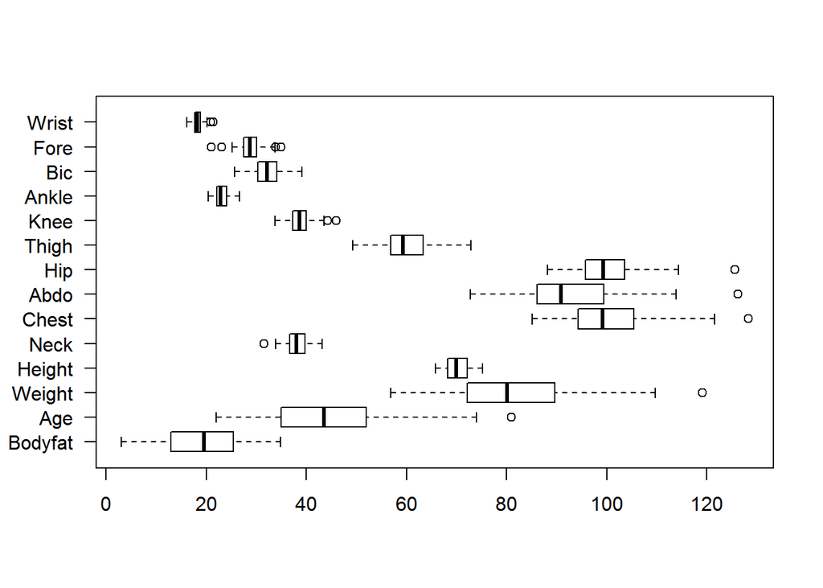

```r
#boxplot the data after removing ID column
bfat = bodyfat[, -1]
boxplot(bfat, horizontal = TRUE, las = 1)
```

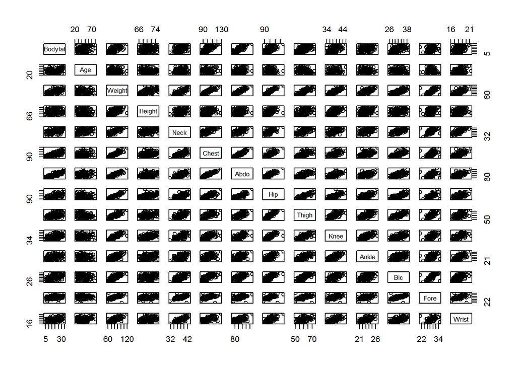

```r
#Scatterplot analysis
pairs(bfat)
```

```r
# correlation heatmap
d3heatmap(cor(bfat), minVal = -1, maxVal = 1)
```

[interactive chart not shown]

## Overview

With linear regression models what we are trying to do is to find the regression parameters to best draw lines to fit the data that we have. This is a supervised learning problem.

We do not cover the imputation of missing values here. Interested parties can look at the following R libraries for further information on missing value imputation. mice / mi / Amelia

In this course we are focused on model selection. The more different input variables the more possible models we have. for example with 4 input variables, var_1, var_2, var_3, var_4

We can have these models:

- Output = parameter_1 * var_1 + parameter_2 * var_2
- Output = parameter_1 * var_2 + parameter_2 * var_3
- Output = parameter_1 * var_1 + parameter_2 * var_2 + parameter_3 * var_3
- Output = parameter_1 * var_1 + parameter_2 * var_2 * var_3

plus many more combinations

How can we choose between which ones to use?

Common Terminology for model selection:

- Null model - Model consisting of just a fixed number
- Full model - Model with every single variable eg for our four factors above it would be
  - Output = parameter_1 * var_1 + parameter_2 * var_2 + parameter_3 * var_3 + parameter_4 * var_4

## Model Fitting

#### Simple linear model

We can fit a simple linear model using the lm function. Bodyfat ~ . means using the Bodyfat variable as our output fit the Full model with all the parameters. Note we don’t multiply any variables together. If we want to do this we need to manually put this in.

```r
Full_Model = lm(Bodyfat ~ . , data = bfat)

# standard R model diagnostics
summary(Full_Model)
```

```
##
## Call:
## lm(formula = Bodyfat ~ ., data = bfat)
##
## Residuals:
##     Min      1Q  Median      3Q     Max
## -9.3767 -2.5514 -0.1723  2.6391  9.1393
##
## Coefficients:
##               Estimate Std. Error t value Pr(>|t|)
## (Intercept) -52.553646  40.062856  -1.312   0.1922
## Age           0.009288   0.043470   0.214   0.8312
## Weight       -0.271016   0.243569  -1.113   0.2682
## Height        0.258388   0.320810   0.805   0.4223
## Neck         -0.592669   0.322125  -1.840   0.0684 .
## Chest         0.090883   0.164738   0.552   0.5822
## Abdo          0.995184   0.123072   8.086 7.29e-13 ***
## Hip          -0.141981   0.204533  -0.694   0.4890
## Thigh         0.101272   0.200714   0.505   0.6148
## Knee         -0.096682   0.325889  -0.297   0.7673
## Ankle        -0.048017   0.507695  -0.095   0.9248
## Bic           0.075332   0.244105   0.309   0.7582
## Fore          0.412107   0.272144   1.514   0.1327
## Wrist        -0.263067   0.745145  -0.353   0.7247
## ---
## Signif. codes:  0 '***' 0.001 '**' 0.01 '*' 0.05 '.' 0.1 ' ' 1
##
## Residual standard error: 4.081 on 114 degrees of freedom
## Multiple R-squared:  0.7519, Adjusted R-squared:  0.7236
## F-statistic: 26.57 on 13 and 114 DF,  p-value: < 2.2e-16
```

Standard model diagnosis charts

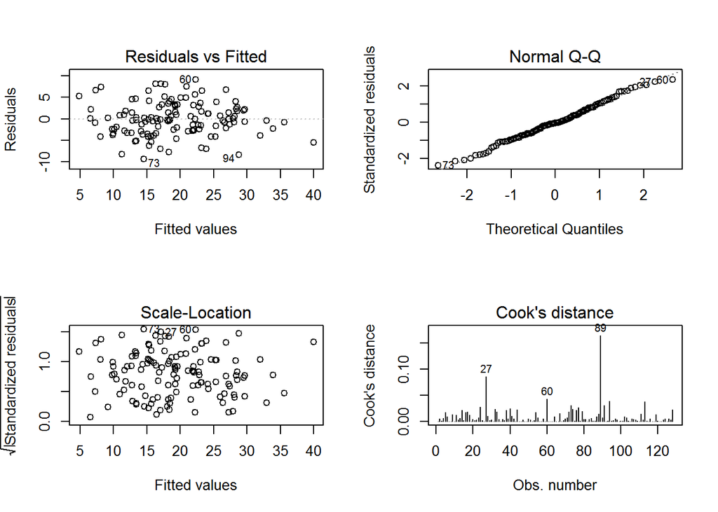

```r
# this command gives us a 2x2 grid of graphs
par(mfrow = c(2,2))
plot(Full_Model, which = c(1,2,3,4), add.smooth = FALSE)
```

#### Model Comparison Tools

So How we compare different models against each other? We can use:

- Adjusted R-Squared

##### Adjusted R-Squared

Adjusted R-Squared is basically the R-squared scaled for the number of parameters fitted. It reduces the R-Squared depending on the number of inputs. This stems from the concept that: The simpler the model the more useful it will probably be.

```r
# we will use the Full_Model from above to show how to extract this information
# from the Model object
summary(Full_Model)$r.squared # normal R.squared
```

```
## [1] 0.7518557
```

```r
summary(Full_Model)$adj.r.squared # adjusted R.squared
```

```
## [1] 0.7235585
```

For this section on we will load in new data:

```r
data("fev", package="mplot")
fem.fev = subset(fev, subset = sex == 0)
y = fem.fev$fev
x = fem.fev$age
```

Lets look at the difference between R-Squared and Adjusted R-Squared

```r
r2 = ar2 = NULL
for (d in 1:16) {
  fit = lm(y ~ poly(x, degree = d))
  r2[d] = summary(fit)$r.squared
  ar2[d] = summary(fit)$adj.r.squared
}
round(rbind(r2, ar2), 3)
```

```
##      [,1]  [,2]  [,3]  [,4]  [,5]  [,6]  [,7]  [,8]  [,9] [,10] [,11]
## r2  0.546 0.621 0.622 0.640 0.641 0.642 0.642 0.642 0.644 0.646 0.648
## ar2 0.545 0.618 0.618 0.636 0.635 0.635 0.634 0.633 0.634 0.634 0.636
##     [,12] [,13] [,14] [,15] [,16]
## r2  0.649 0.649 0.650 0.650 0.650
## ar2 0.635 0.634 0.634 0.633 0.632
```

Lets plot them together The dotted lines show the best model (model with highest R-Squared / Adjusted R-Squared) Notice how R-Squared picked the model with the model inputs But the adjusted R-Squared didn’t.

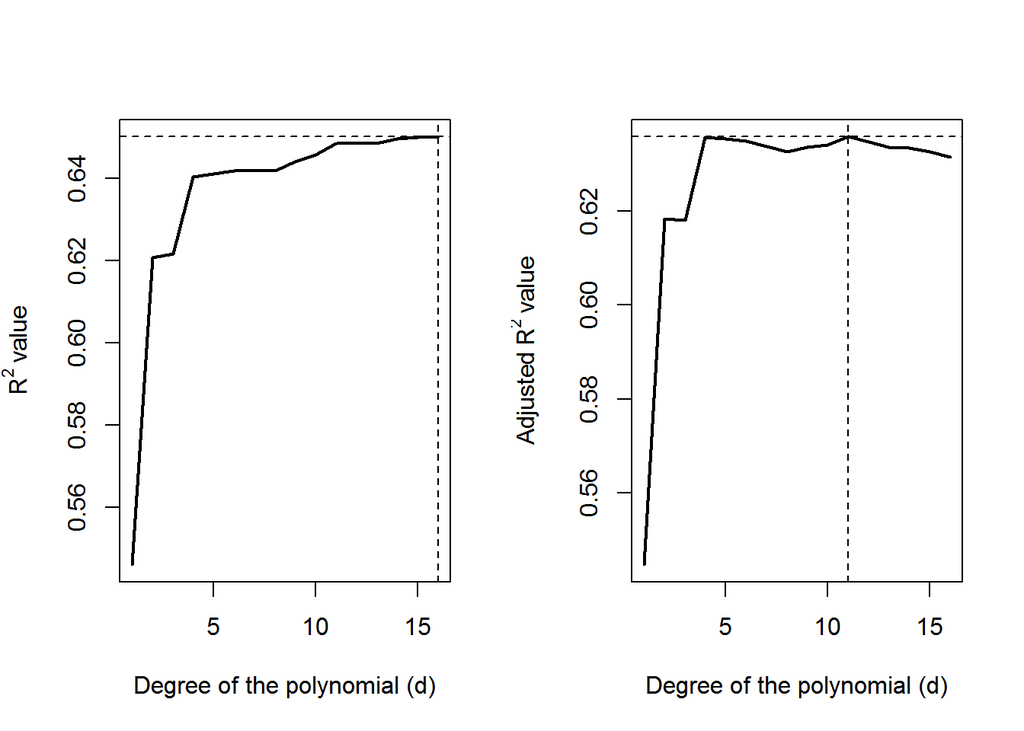

```r
par(mfrow = c(1,2))

# R-squared
plot(1:16, r2, type = "l", xlab = "Degree of the polynomial (d)",
     ylab = expression(R^2 ~ value), lwd = 2)
abline(h = max(r2), lty = 2)
abline(v = which.max(r2), lty = 2)

# adjusted R-squared
plot(1:16, ar2, type = "l", xlab = "Degree of the polynomial (d)",
     ylab = expression(Adjusted ~ R^2 ~ value), lwd = 2)
abline(h = max(ar2), lty = 2)
abline(v = which.max(ar2), lty = 2)
```

##### Selection Criteria

An alternative way to select models is to use selection criteria like:

- Akaike’s Information Criterion (AIC)
- Bayesian Information Criterion (AIC)

Calculating AIC and BIC

```r
aic = bic = NULL
for (d in 1:16) {
  fit = lm(y ~ poly(x, degree = d))
  aic[d] = -2 * logLik(fit) + 2 * (d + 2)  # AIC(fit)
  bic[d] = -2 * logLik(fit) + (d + 2) * log(length(y))  # AIC(fit,k = log(length(y)))
}
round(rbind(aic, bic))
```

```
##     [,1] [,2] [,3] [,4] [,5] [,6] [,7] [,8] [,9] [,10] [,11] [,12] [,13]
## aic  378  323  324  310  311  313  315  317  317   317   317   319   321
## bic  389  338  343  333  338  343  349  354  358   362   366   371   377
##     [,14] [,15] [,16]
## aic   322   323   325
## bic   382   387   393
```

The lower the AIC and the BIC the better.

Lets put these on a plot

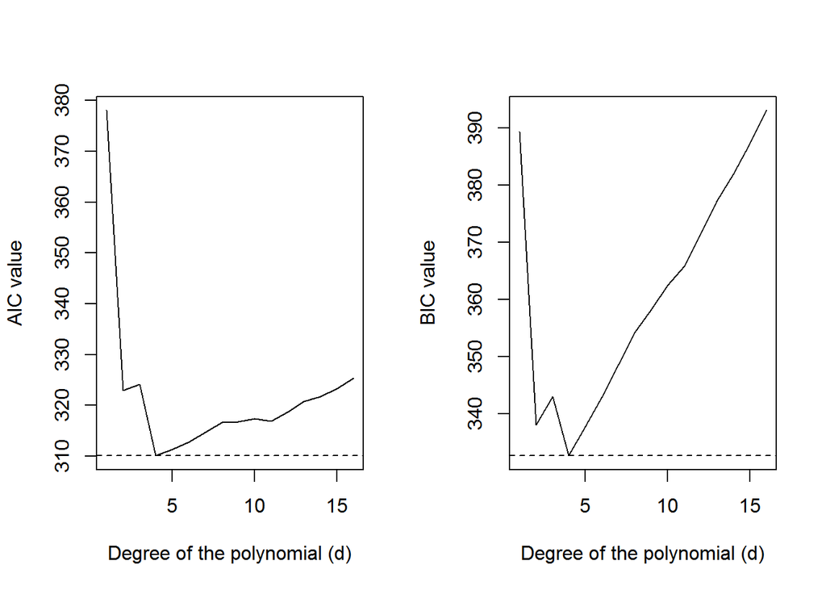

```r
par(mfrow = c(1,2))

plot(1:16, aic, type = "l", xlab = "Degree of the polynomial (d)", ylab = "AIC value")
abline(h = min(aic), lty = 2)

plot(1:16, bic, type = "l", xlab = "Degree of the polynomial (d)", ylab = "BIC value")
abline(h = min(bic), lty = 2)
```

So far what we have tried to do is to test every single model and use R^2 / AIC / BIC to help us find the right one. We could however use an algorithm that will automatically iterate through models to find the best one.

Let’s use a new dataset of US crime figures

```r
data("UScrime",package = "MASS")
dim(UScrime)
```

```
## [1] 47 16
```

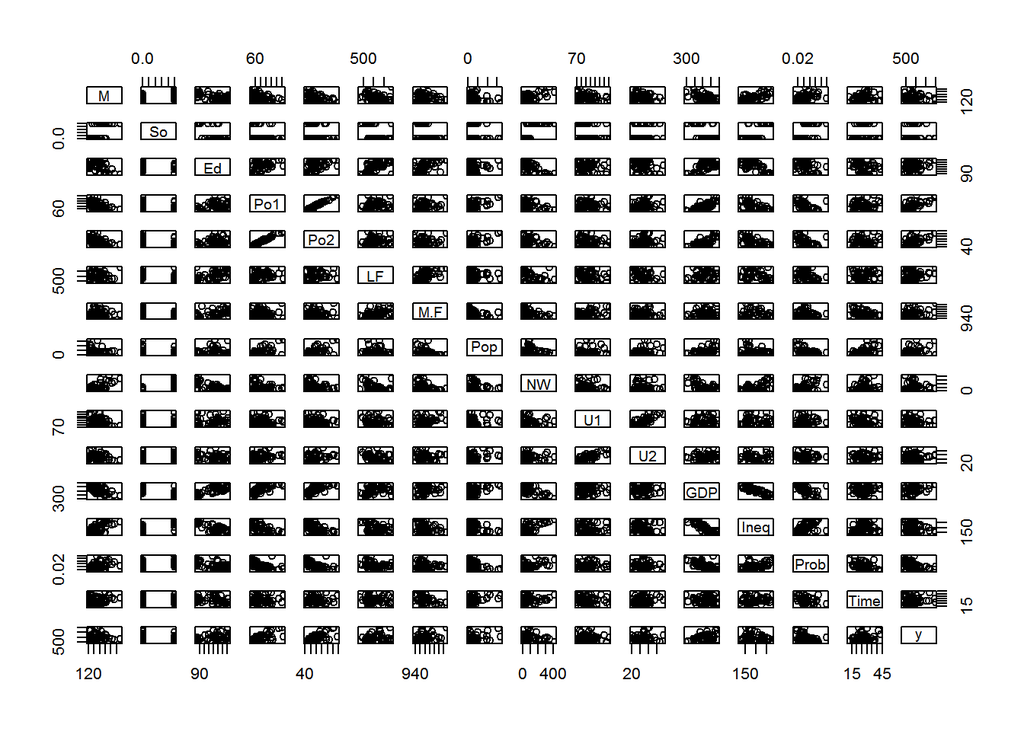

```r
pairs(UScrime)
```